# Give Me Some Credit: Machine learning to predict financial difficulty

## R Markdown

You can try the [Shiny App](https://peymanh.shinyapps.io/loan_default) made for this project.

Banks play a crucial role in market economies. They decide who can get finance and on what terms and can make or break investment decisions. For markets and society to function, individuals and companies need access to credit.

Credit scoring algorithms, which make a guess at the probability of default, are the method banks use to determine whether or not a loan should be granted. Here I try to improve on the state of the art in credit scoring, by predicting the probability that somebody will experience financial distress in the next two years.

This project was a [Kaggle competition](https://www.kaggle.com/c/GiveMeSomeCredit).

## Data

Data contains a label (SeriousDlqin2yrs (Delinquent):Person experienced 90 days past due delinquency or worse ) and the following information about each person.

- RevolvingUtilizationOfUnsecuredLines (Line_usage): Total balance on credit cards and personal lines of credit except real estate and no installment debt like car loans divided by the sum of credit limits
- age (age): Age of borrower in years
- NumberOfTime30-59DaysPastDueNotWorse (Late30_59): Number of times borrower has been 30-59 days past due but no worse in the last 2 years.
- DebtRatio (Debt_ratio): Monthly debt payments, alimony,living costs divided by monthy gross income
- MonthlyIncome Monthly (Monthly_income): income
- NumberOfOpenCreditLinesAndLoans (Credit_lines): Number of Open loans (installment like car loan or mortgage) and Lines of credit (e.g. credit cards)
- NumberOfTimes90DaysLate (Late90): Number of times borrower has been 90 days or more past due.
- NumberRealEstateLoansOrLines (Real_estate_loans): Number of mortgage and real estate loans including home equity lines of credit
- NumberOfTime60-89DaysPastDueNotWorse (Late60_89): Number of times borrower has been 60-89 days past due but no worse in the last 2 years.
- NumberOfDependents (Dependents): Number of dependents in family excluding themselves (spouse, children etc.)

```r
loan_data<- read.csv("cs-training.csv", header = TRUE)
loan_data <- data.table(loan_data)
loan_data <- loan_data[, !"X", with=FALSE]

colnames(loan_data) <- c("Delinquent", "Line_usage", "age", "Late30_59",
                         "Debt_ratio", "Monthly_income", "Credit_lines",
                         "Late90", "Real_estate_loans", "Late60_89",
                         "Dependents")

summary(loan_data)
```

```
##    Delinquent        Line_usage            age          Late30_59
##  Min.   :0.00000   Min.   :    0.00   Min.   :  0.0   Min.   : 0.000
##  1st Qu.:0.00000   1st Qu.:    0.03   1st Qu.: 41.0   1st Qu.: 0.000
##  Median :0.00000   Median :    0.15   Median : 52.0   Median : 0.000
##  Mean   :0.06684   Mean   :    6.05   Mean   : 52.3   Mean   : 0.421
##  3rd Qu.:0.00000   3rd Qu.:    0.56   3rd Qu.: 63.0   3rd Qu.: 0.000
##  Max.   :1.00000   Max.   :50708.00   Max.   :109.0   Max.   :98.000
##
##    Debt_ratio       Monthly_income     Credit_lines        Late90
##  Min.   :     0.0   Min.   :      0   Min.   : 0.000   Min.   : 0.000
##  1st Qu.:     0.2   1st Qu.:   3400   1st Qu.: 5.000   1st Qu.: 0.000
##  Median :     0.4   Median :   5400   Median : 8.000   Median : 0.000
##  Mean   :   353.0   Mean   :   6670   Mean   : 8.453   Mean   : 0.266
##  3rd Qu.:     0.9   3rd Qu.:   8249   3rd Qu.:11.000   3rd Qu.: 0.000
##  Max.   :329664.0   Max.   :3008750   Max.   :58.000   Max.   :98.000
##                     NA's   :29731
##  Real_estate_loans   Late60_89         Dependents
##  Min.   : 0.000    Min.   : 0.0000   Min.   : 0.000
##  1st Qu.: 0.000    1st Qu.: 0.0000   1st Qu.: 0.000
##  Median : 1.000    Median : 0.0000   Median : 0.000
##  Mean   : 1.018    Mean   : 0.2404   Mean   : 0.757
##  3rd Qu.: 2.000    3rd Qu.: 0.0000   3rd Qu.: 1.000
##  Max.   :54.000    Max.   :98.0000   Max.   :20.000
##                                      NA's   :3924
```

Two features have NAs. Number of dependents and monthly income. These issues need to be fixed before starting to train machine learning algorithms.

## Data Partitioning

```r
INtraining_validation<- createDataPartition(loan_data$Delinquent,
                                            p=0.8,
                                            list=FALSE)
training_validation<- loan_data[INtraining_validation,]
testing<- loan_data[-INtraining_validation,]

INtraining<- createDataPartition(training_validation$Delinquent,
                                 p=0.8,
                                 list=FALSE)
training<- training_validation[INtraining,]
validation<- training_validation[-INtraining,]
```

We divided our dataset into train, validation and test form the begining of the analysis. There are 96000 records in the training dataset, 24000 records in the validation dataset, and 30000 records in the testing dataset.

## Exploratory Data Analysis

In this section we will take a look at the data and some univariate and bivariate plots.

```r
delinq_ratio <- sum(training$Delinquent)/dim(training)[1]
```

number of delinquents is: 6321 , which is only 0.0658438 of all the training data.

### Distribution of features

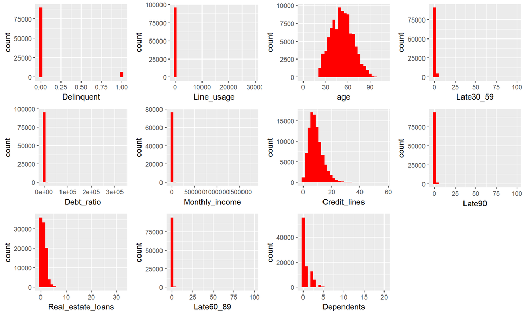

```r
g1 <- ggplot(aes(x=Delinquent), data=training)+
    geom_histogram(fill= 'red')
g2 <- ggplot(aes(x=Line_usage), data=training)+
    geom_histogram(fill= 'red')
g3 <- ggplot(aes(x=age), data=training)+
    geom_histogram(fill= 'red')
g4 <- ggplot(aes(x=Late30_59), data=training)+
    geom_histogram(fill= 'red')
g5 <- ggplot(aes(x=Debt_ratio), data=training)+
    geom_histogram(fill= 'red')
g6 <- ggplot(aes(x=Monthly_income), data=training)+
    geom_histogram(fill= 'red')
g7 <- ggplot(aes(x=Credit_lines), data=training)+
    geom_histogram(fill= 'red')
g8 <- ggplot(aes(x=Late90), data=training)+
    geom_histogram(fill= 'red')
g9 <- ggplot(aes(x=Real_estate_loans), data=training)+
    geom_histogram(fill= 'red')
g10 <- ggplot(aes(x=Late60_89), data=training)+
    geom_histogram(fill= 'red')
g11 <- ggplot(aes(x=Dependents), data=training)+
    geom_histogram(fill= 'red')
grid.arrange(g1,g2,g3,g4,g5,g6,g7,g8,g9,g10,g11, ncol=4)
```

```r
num_line_overage <- dim(training[training$Line_usage>1])[1]
num_line_overage_del <- sum(training$Delinquent[training$Line_usage>1])
dlq_if_overage <- num_line_overage_del/ num_line_overage
summary(training$Line_usage)
```

```
##      Min.   1st Qu.    Median      Mean   3rd Qu.      Max.
##     0.000     0.030     0.153     5.462     0.556 29110.000
```

probability of being delinquent if your balance is higher than limit is 0.3724466, which suggest a strong association

```r
under_18 <- sum(training$age<18)
```

There is 1 applicant in the system, which does not make sense and needs to be removed.

```r
table(training$Dependents)
```

```
##
##     0     1     2     3     4     5     6     7     8     9    10    20
## 55760 16726 12420  6150  1834   464   104    21    18     1     3     1
```

Most applicants do not have any dependents and there is one with 20. However, we do not remove these records, since it is possible that some applicants have a lot of dependents.

```r
table(training$Real_estate_loans)
```

```
##
##     0     1     2     3     4     5     6     7     8     9    10    11
## 35998 33420 20131  4093  1420   442   201   109    60    47    25    13
##    12    13    14    15    16    17    18    19    20    21    23    25
##     8     9     4     5     2     2     1     2     1     1     2     3
##    32
##     1
```

Most applicants do not have more than a few real estate loans. However, there are some with more than 20. Although it is possible that an applicant has more than 20 loans, these records are going to be removed since they are outliers.

```r
summary(training$Monthly_income)
```

```
##    Min. 1st Qu.  Median    Mean 3rd Qu.    Max.    NA's
##       0    3400    5400    6669    8250 1794000   19126
```

The monthly income feature is the most challenging feature in this analysis. It is highly skewed and there are a lot of NAs. NAs will be imputed and records that have monthly income of more than $200,000 will be removed.

```r
num_late <- length(training$Delinquent[(training$Late30_59>30)&
                                           (training$Late90>30) &
                                           (training$Late60_89>30)])

num_late_dlq <- sum(training$Delinquent[(training$Late30_59>30)&
                                            (training$Late90>30) &
                                            (training$Late60_89>30)])
dlq_if_late <- num_late_dlq/num_late
table(training$Late30_59)
```

```
##
##     0     1     2     3     4     5     6     7     8     9    10    12
## 80610 10297  2923  1159   478   208   100    30    14     6     2     2
##    13    96    98
##     1     4   166
```

```r
table(training$Late60_89)
```

```
##
##     0     1     2     3     4     5     6     7     8     9    11    96
## 91174  3629   710   214    64    21    10     5     1     1     1     4
##    98
##   166
```

```r
table(training$Late90)
```

```
##
##     0     1     2     3     4     5     6     7     8     9    10    11
## 90692  3333  1002   421   191    78    45    25    16    12     4     3
##    12    13    15    17    96    98
##     1     4     2     1     4   166
```

There are people that have missed more than 90 loan payments in the past. At first, my idea was to remove these but then I realized that this might be a very important feature to identify the risky applicants. I found out that 0.6117647 of people who have missed more than 30 payments are labeled and delinquent.

## Data cleaning and transformation

Line usage, debt ratio, and monthly income is highly skewed. In order to prepare the data for machine learning, log transformation was performed on these features. In addition, since NA in number of dependents probably mean 0, we set NAs for this feature 0.

```r
training <- training[training$age>18]
training <- training[training$Real_estate_loans<20]
training <- training[training$Monthly_income<200000 |
                         is.na(training$Monthly_income)]

loan_transformer <- function(data){
    data$Log_line_usage <- log(data$Line_usage+1e-8)
    data$Log_debt_ratio <- log(data$Debt_ratio+1e-8)
    data$Log_monthly_income <- log(data$Monthly_income+1e-8)
    data <- data[,c("Line_usage", "Debt_ratio", "Monthly_income"):=NULL]
    data$Dependents[is.na(data$Dependents)] <- 0
    data$Delinquent <- factor(data$Delinquent, levels=c(0,1),
                                 labels=c("Safe", "Risky"))
    return(data)
}

training <- loan_transformer(training)
testing <- loan_transformer(testing)
validation <- loan_transformer(validation)
```

## Imputation

The only feature with a lot of NAs remaining is the monthly income. My idea initially was to use KNN to imput these values but then moved to using a linear regression due to the higher speed of the algorithm.

```r
income_Imputer <- train(Log_monthly_income ~ .,
                     data = training[!is.na(training$Log_monthly_income)
                                     , !c("Delinquent"), with=FALSE],
                     method="lm")


training$Log_monthly_income[is.na(training$Log_monthly_income)]=
    predict(income_Imputer, newdata = training[is.na(training$Log_monthly_income)
                                           , !c("Delinquent"), with=FALSE] )

testing$Log_monthly_income[is.na(testing$Log_monthly_income)]=
    predict(income_Imputer, newdata = testing[is.na(testing$Log_monthly_income)
                                               , !c("Delinquent"), with=FALSE] )


validation$Log_monthly_income[is.na(validation$Log_monthly_income)]=
    predict(income_Imputer, newdata = validation[is.na(validation$Log_monthly_income)
                                              , !c("Delinquent"), with=FALSE] )
```

## Bi-variate Analysis

```r
hetcor(training, std.err=F )
```

```
##
## Two-Step Estimates
##
## Correlations/Type of Correlation:
##                    Delinquent        age  Late30_59 Credit_lines
## Delinquent                  1 Polyserial Polyserial   Polyserial
## age                   -0.2196          1    Pearson      Pearson
## Late30_59              0.2653   -0.05937          1      Pearson
## Credit_lines         -0.06995     0.1602   -0.05071            1
## Late90                 0.2485   -0.05726     0.9811      -0.0777
## Real_estate_loans    -0.02314    0.04264   -0.02898       0.4298
## Late60_89              0.2174    -0.0533      0.985     -0.06753
## Dependents            0.08608     -0.213  -0.001581      0.06745
## Log_line_usage         0.2154    -0.1114    0.04603      0.06116
## Log_debt_ratio       -0.01982     0.0287    -0.1148       0.1713
## Log_monthly_income    0.01374    0.01813   -0.02412        0.119
##                        Late90 Real_estate_loans  Late60_89 Dependents
## Delinquent         Polyserial        Polyserial Polyserial Polyserial
## age                   Pearson           Pearson    Pearson    Pearson
## Late30_59             Pearson           Pearson    Pearson    Pearson
## Credit_lines          Pearson           Pearson    Pearson    Pearson
## Late90                      1           Pearson    Pearson    Pearson
## Real_estate_loans    -0.04539                 1    Pearson    Pearson
## Late60_89              0.9916           -0.0388          1    Pearson
## Dependents          -0.008947            0.1332    -0.0101          1
## Log_line_usage        0.03726           0.02345    0.03374      0.072
## Log_debt_ratio        -0.1236            0.2278    -0.1214   -0.03636
## Log_monthly_income   -0.02978             0.104   -0.02864     0.1093
##                    Log_line_usage Log_debt_ratio Log_monthly_income
## Delinquent             Polyserial     Polyserial         Polyserial
## age                       Pearson        Pearson            Pearson
## Late30_59                 Pearson        Pearson            Pearson
## Credit_lines              Pearson        Pearson            Pearson
## Late90                    Pearson        Pearson            Pearson
## Real_estate_loans         Pearson        Pearson            Pearson
## Late60_89                 Pearson        Pearson            Pearson
## Dependents                Pearson        Pearson            Pearson
## Log_line_usage                  1        Pearson            Pearson
## Log_debt_ratio             0.1229              1            Pearson
## Log_monthly_income        0.03258        -0.4875                  1
```

Figure 2 demonstrates that a large portion of Risky applicatant have higher revolving line usages and have missed payments for over 90 days.

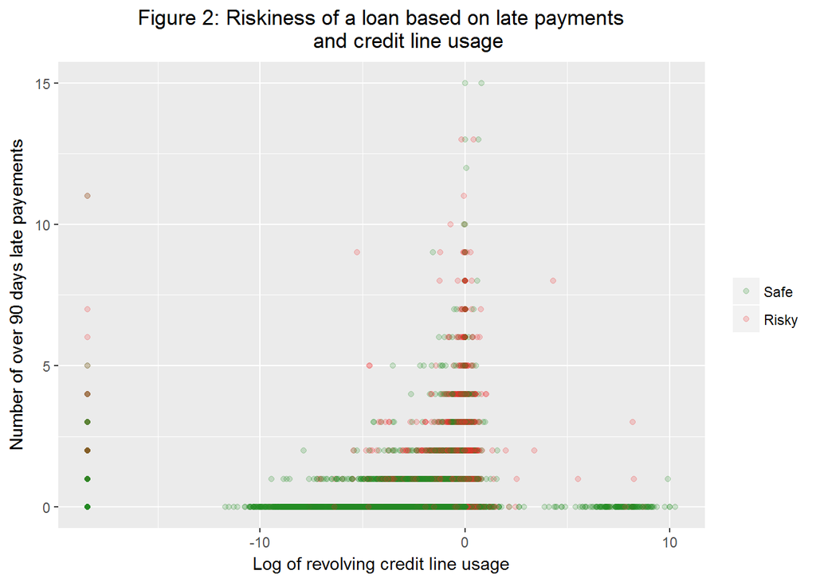

```r
g_f_3 <- ggplot(aes(y=Late90,x=Log_line_usage),data=training)+
    geom_point(aes(color=Delinquent), alpha=0.2)+
    scale_colour_manual(name="",  values =c("forestgreen",  "firebrick2"))+
    ylim(c(0,15))+ylab('Number of over 90 days late payements')+
    xlab('Log of revolving credit line usage')+
    labs(title =
             "Figure 2: Riskiness of a loan based on late payments
         and credit line usage") +
    theme(plot.title = element_text(hjust = 0.5))

g_f_3
```

As it can be seen in Figure 3, debt to income ratio does not create a sensible distiction between the Risky and Safe applicants.

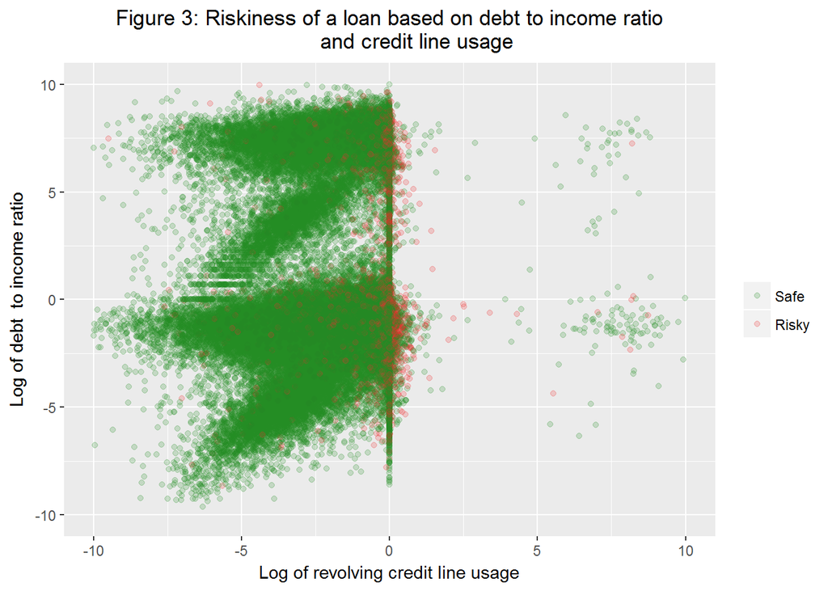

```r
g_f_4 <- ggplot(aes(y=Log_debt_ratio,x=Log_line_usage),data=training)+
    geom_point(aes(color=Delinquent), alpha=0.2)+
    scale_colour_manual(name="",  values =c("forestgreen",  "firebrick2"))+
    ylim(c(-10,10))+
    xlim(c(-10,10))+
    ylab('Log of debt  to income ratio')+
    xlab('Log of revolving credit line usage')+
    labs(title =
             "Figure 3: Riskiness of a loan based on debt to income ratio
         and credit line usage") +
    theme(plot.title = element_text(hjust = 0.5))

g_f_4
```

Figure 4 shows that younger applicant are more probable to be Risky if they have used most of their credit line.

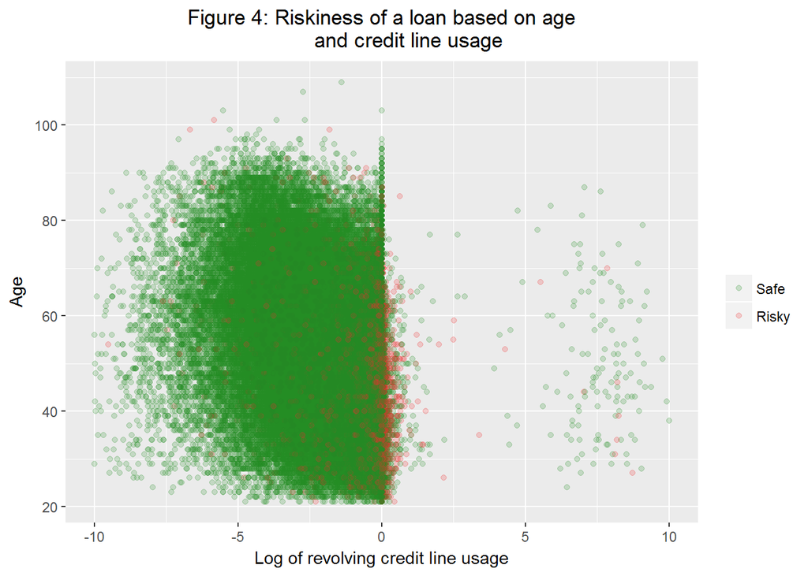

```r
g_f_5 <- ggplot(aes(y=age,x=Log_line_usage),data=training)+
    geom_point(aes(color=Delinquent), alpha=0.2)+
    scale_colour_manual(name="",  values =c("forestgreen",  "firebrick2"))+
    #ylim(c(-10,10))+
    xlim(c(-10,10))+
    ylab('Age')+
    xlab('Log of revolving credit line usage')+
    labs(title =
             "Figure 4: Riskiness of a loan based on age
         and credit line usage") +
    theme(plot.title = element_text(hjust = 0.5))

g_f_5
```

## Machine Learning

In this part, we will focus on training different machine learning algorithms on the training dataset. Since we have imbalance data and just under 7% of the data is Risky. Therefore, I am going to use ROC to evaluate and select the models. All algorithms are tuned using a 5-fold cross validation proecss.

### Decision Tree

```r
train_control <- trainControl(method="repeatedcv", number=5, summaryFunction = twoClassSummary,
                              classProbs = TRUE, savePredictions = T)

dt <- train(Delinquent~., data=training, method='rpart',
            trControl=train_control, tuneLength = 3, metric = "ROC")
dt_prediction <- predict(dt, newdata=validation)
dt_prediction_prob <- predict(dt, newdata=validation, type='prob')
dt
```

```
## CART
##
## 93471 samples
##    10 predictor
##     2 classes: 'Safe', 'Risky'
##
## No pre-processing
## Resampling: Cross-Validated (5 fold, repeated 1 times)
## Summary of sample sizes: 74776, 74777, 74777, 74777, 74777
## Resampling results across tuning parameters:
##
##   cp           ROC        Sens       Spec
##   0.002257336  0.6568804  0.9921393  0.1465698
##   0.004595292  0.6565044  0.9940643  0.1156137
##   0.016204450  0.5914490  0.9938580  0.1007541
##
## ROC was used to select the optimal model using  the largest value.
## The final value used for the model was cp = 0.002257336.
```

ROC of the decision tree algorithm is just 0.657, which is not impressive.

### Random Forest

```r
rf <- train(Delinquent~., data=training, method='rf',
            trControl=train_control, tuneLength = 3, metric = "ROC")
rf_prediction <- predict(rf, newdata=validation)
rf_prediction_prob <- predict(rf, newdata=validation, type='prob')
rf_prediction_test_prob <- predict(rf, newdata=testing, type='prob')
rf
```

```
## Random Forest
##
## 93471 samples
##    10 predictor
##     2 classes: 'Safe', 'Risky'
##
## No pre-processing
## Resampling: Cross-Validated (5 fold, repeated 1 times)
## Summary of sample sizes: 74776, 74777, 74778, 74777, 74776
## Resampling results across tuning parameters:
##
##   mtry  ROC        Sens       Spec
##    2    0.8483385  0.9923226  0.1570461
##    6    0.8433725  0.9871776  0.1981616
##   10    0.8410791  0.9861807  0.1992887
##
## ROC was used to select the optimal model using  the largest value.
## The final value used for the model was mtry = 2.
```

ROC of the random forest algorithm jumped to 0.848, which is a big improvement over the decision tree.

### Extreme Gradient Boosting

```r
train_xgb <- function(training, validation){
    traind <- xgb.DMatrix(data = as.matrix(training[,-1])
                          , label = as.numeric(training$Delinquent=="Risky"))
    validd<- xgb.DMatrix(data = as.matrix(validation[,-1])
                         , label = as.numeric(validation$Delinquent=="Risky"))

    watch_list <- list(train=traind, test=validd)

    Extreme_gb <- xgb.train(data=traind,
                            eta=.01,
                            eval.metric = "error",
                            watchlist=watch_list,
                            max.depth=3,
                            nthread = 6,
                            nround=2000,
                            eval.metric = "auc",
                            objective = "binary:logistic")
    return(Extreme_gb)
}

predict_xgb <- function(Extreme_gb, validation){
    validd<- xgb.DMatrix(data = as.matrix(validation[,-1])
                         , label = as.numeric(validation$Delinquent=="Risky"))
    xgb_prediction_prob<-predict(Extreme_gb,validd)
    return(xgb_prediction_prob)
}

Extreme_gb <- train_xgb(training, validation)
xgb.save(Extreme_gb, "Extreme_gb")
xgb_prediction_prob<-predict_xgb(Extreme_gb,validation)

xgb_prediction <- ifelse(xgb_prediction_prob>0.5, "Risky", "Safe")
prediction_gb <- prediction(xgb_prediction_prob, as.numeric(validation$Delinquent=='Risky'))
auc_gb <- performance(prediction_gb, measure = "auc")
auc_gb <- auc_gb@y.values[[1]]

xgb_prediction_test_prob<-predict_xgb(Extreme_gb,testing)
prediction_gb_t <- prediction(xgb_prediction_test_prob, as.numeric(testing$Delinquent=='Risky'))
auc_gb_t <- performance(prediction_gb_t, measure = "auc")
auc_gb_t <- auc_gb_t@y.values[[1]]
```

ROC of the XGB algorithm jumped to 0.8648479, which is still increasing over ROC of the random forest.

### Deep Learning

```r
write.csv(training, 'trainx.csv', row.names=FALSE)
write.csv(validation, 'validx.csv', row.names=FALSE)
write.csv(testing, 'testx.csv', row.names=FALSE)
train_dl <- function(training, validation){
    write.csv(training, 'traintemp.csv', row.names=FALSE)
    write.csv(validation, 'validtemp.csv', row.names=FALSE)
    h2o.init(nthreads=-1, max_mem_size="2G")
    h2o.removeAll()
    trainh <- h2o.importFile(path = normalizePath("C:/Github/GiveMeCredit/traintemp.csv"))
    validh <- h2o.importFile(path = normalizePath("C:/Github/GiveMeCredit/validtemp.csv"))
    response <- "Delinquent"
    predictors <- setdiff(names(trainh), response)
    hyper_params <- list(
        activation=c("RectifierWithDropout", "TanhWithDropout"),
        hidden=list(c(50,50), c(100,100), c(50,25)))
    dl_random_grid <- h2o.grid(
        algorithm="deeplearning",
        grid_id = "dl_grid_random",
        training_frame=trainh,
        validation_frame=validh,
        x=predictors,
        y=response,
        nfolds=5,
        stopping_metric="logloss",
        stopping_tolerance=2e-3,
        fold_assignment="Stratified",
        hyper_params = hyper_params,
        seed = 42)
    grid <- h2o.getGrid("dl_grid_random")
    DL_model <- h2o.getModel(grid@model_ids[[1]])
    return (DL_model)
}

predict_dl <- function(DL_model, validation){
    write.csv(validation, 'validtemp.csv', row.names=FALSE)
    validh <- h2o.importFile(path = normalizePath("C:/Github/GiveMeCredit/validtemp.csv"))
    DL_predict <- h2o.predict(DL_model, validh)
    DL_prediction_prob <- as.data.table(DL_predict[,c("Risky", "Safe")])
    DL_prediction_prob <- DL_prediction_prob$Risky
    return(DL_prediction_prob)
}

DL_model <- train_dl(training, validation)
DL_prediction_prob <-predict_dl(DL_model, validation)
h2o.saveModel(object=DL_model,path=getwd(), force=TRUE)
```

```r
DL_model
```

```
## Model Details:
## ==============
##
## H2OBinomialModel: deeplearning
## Model ID:  dl_grid_random_model_2
## Status of Neuron Layers: predicting Delinquent, 2-class classification, bernoulli distribution, CrossEntropy loss, 11,402 weights/biases, 141.3 KB, 1,068,718 training samples, mini-batch size 1
##   layer units             type dropout       l1       l2 mean_rate
## 1     1    10            Input  0.00 %
## 2     2   100 RectifierDropout 50.00 % 0.000000 0.000000  0.011555
## 3     3   100 RectifierDropout 50.00 % 0.000000 0.000000  0.013849
## 4     4     2          Softmax         0.000000 0.000000  0.005826
##   rate_rms momentum mean_weight weight_rms mean_bias bias_rms
## 1
## 2 0.017258 0.000000    0.030975   0.246449  0.214238 0.199113
## 3 0.029528 0.000000   -0.045251   0.109275  0.455186 0.291089
## 4 0.004444 0.000000    0.021977   0.488353 -0.012733 0.133074
##
##
## H2OBinomialMetrics: deeplearning
## ** Reported on training data. **
## Description: Metrics reported on temporary training frame with 9963 samples
##
## MSE:  0.05161263
## R^2:  0.1993054
## LogLoss:  0.1860417
## AUC:  0.8599351
## Gini:  0.7198702
##
## Confusion Matrix for F1-optimal threshold:
##        Risky Safe    Error       Rate
## Risky    134  556 0.805797   =556/690
## Safe      88 9185 0.009490   =88/9273
## Totals   222 9741 0.064639  =644/9963
##
## Maximum Metrics: Maximum metrics at their respective thresholds
##                         metric threshold    value idx
## 1                       max f1  0.568648 0.966130 329
## 2                       max f2  0.279554 0.985378 398
## 3                 max f0point5  0.820398 0.957332 211
## 4                 max accuracy  0.568648 0.935361 329
```

[output cut: 49 more lines]

```
## Safe     592 86677 0.006784   =592/87269
## Totals  1487 91984 0.063110  =5899/93471
##
## Maximum Metrics: Maximum metrics at their respective thresholds
##                         metric threshold    value idx
## 1                       max f1  0.500902 0.967091 332
## 2                       max f2  0.112766 0.985986 399
## 3                 max f0point5  0.788837 0.958929 212
## 4                 max accuracy  0.557595 0.936900 312
## 5                max precision  0.995852 0.995010   6
## 6                   max recall  0.112766 1.000000 399
## 7              max specificity  0.998634 0.999678   0
## 8             max absolute_mcc  0.796593 0.384388 208
## 9   max min_per_class_accuracy  0.934738 0.773299 102
## 10 max mean_per_class_accuracy  0.929617 0.775206 107
```

ROC of the deep learning is 0.854 , It is not as high as XGB at this stage.

### gbm

```r
train_ada <- function(training){
    gbm_ada <- train(Delinquent~.
                     ,data = training
                     ,method = "gbm"
                     ,trControl = train_control
                     ,verbose = TRUE
                     ,tuneLength = 3
                     , metric = 'ROC')
    return(gbm_ada)
}
predict_ada <- function(gbm_ada,validation){
    ada_prediction_prob <- predict(gbm_ada, newdata=validation, type='prob')
    ada_prediction_prob <- ada_prediction_prob$Risky
    return (ada_prediction_prob)
}
gbm_ada<- train_ada(training)
ada_prediction_prob <- predict_ada(gbm_ada, validation)
save(gbm_ada, file="gbm_ada.RData")
```

```r
gbm_ada
```

```
## Stochastic Gradient Boosting
##
## 93471 samples
##    10 predictor
##     2 classes: 'Safe', 'Risky'
##
## No pre-processing
## Resampling: Cross-Validated (5 fold, repeated 1 times)
## Summary of sample sizes: 74777, 74777, 74778, 74776, 74776
## Resampling results across tuning parameters:
##
##   interaction.depth  n.trees  ROC        Sens       Spec
##   1                   50      0.8512822  0.9925747  0.1496282
##   1                  100      0.8559900  0.9909132  0.1786504
##   1                  150      0.8578419  0.9906840  0.1839722
##   2                   50      0.8555636  0.9915778  0.1713943
##   2                  100      0.8596581  0.9905121  0.1886513
##   2                  150      0.8611443  0.9900079  0.1954230
##   3                   50      0.8583642  0.9915090  0.1730090
##   3                  100      0.8611814  0.9900996  0.1936494
##   3                  150      0.8618429  0.9896871  0.1984869
##
## Tuning parameter 'shrinkage' was held constant at a value of 0.1
##
## Tuning parameter 'n.minobsinnode' was held constant at a value of 10
## ROC was used to select the optimal model using  the largest value.
## The final values used for the model were n.trees = 150,
##  interaction.depth = 3, shrinkage = 0.1 and n.minobsinnode = 10.
```

ROC of the gbm is 0.862 , It is not as high as XGB but higher than deep learning and random forest.

### Naive Bayes

```r
train_nb <- function(training){
    nb <- train(Delinquent~.
                     ,data = training
                     ,method = "nb"
                     ,trControl = train_control
                     ,verbose = TRUE
                     ,tuneLength = 3
                     , metric = 'ROC')
    return(nb)
}

predict_nb <- function(nb, validation){
    nb_prediction_prob <- predict(nb, newdata=validation, type='prob')
    nb_prediction_prob <- nb_prediction_prob$Risky
    return (nb_prediction_prob)
}

nb <- train_nb(training)
nb_prediction_prob <- predict_nb(nb, validation)
save(nb, file="nb.RData")
```

```r
nb
```

```
## Naive Bayes
##
## 93471 samples
##    10 predictor
##     2 classes: 'Safe', 'Risky'
##
## No pre-processing
## Resampling: Cross-Validated (5 fold, repeated 1 times)
## Summary of sample sizes: 74778, 74776, 74777, 74776, 74777
## Resampling results across tuning parameters:
##
##   usekernel  ROC        Sens       Spec
##   FALSE      0.7321494  0.9984072  0.01096254
##    TRUE      0.8523893  0.9739312  0.33811494
##
## Tuning parameter 'fL' was held constant at a value of 0
## Tuning
##  parameter 'adjust' was held constant at a value of 1
## ROC was used to select the optimal model using  the largest value.
## The final values used for the model were fL = 0, usekernel = TRUE
##  and adjust = 1.
```

ROC of the Naive Bayes is 0.852 , It is not as high as XGB but it still can be useful in model stacking.

### Model Stacking

Model Satcking is a well-known practice to boost model performance. Here we used a 5-fold stratified shuffel and trained the XGB, gbm, and deep learning models on 4 folds and then predicted the fifth fold. This process was performed 5 times and at the end a new dataset was created. The columns in this dataset are Delinquent (label), risk probability from XGB,risk probability from gbm, and risk probability from deep learning.

Finally XGB was once more used to tune a new model on the new dataset using cross validation.

```r
ensemble_prepar_it <- function(valid_train){
    ens_df <- data.frame(Delinquent= factor(),
                         xgb=double(),
                         dl=double(),
                         ada=double(),
                         stringsAsFactors=FALSE)
    folds <- createFolds(valid_train$Delinquent, k=5)
    for (i in 1:5){
        this_fold <- paste0("Fold", toString(i))
        indexes <- folds[[this_fold]]
        in_train <- valid_train[-indexes,]
        in_test <- valid_train[indexes,]
        xgb <- train_xgb(in_train, in_test)
        dl <- train_dl(in_train, in_test)
        ada <- train_ada(in_train)
        xgb_prob <- predict_xgb(xgb, in_test)
        dl_prob <- predict_dl(dl, in_test)
        ada_prob <- predict_ada(ada, in_test)
        ens_df_temp <- data.frame(Delinquent= in_test$Delinquent,
                                  xgb=xgb_prob,
                                  dl=dl_prob,
                                  ada=ada_prob,
                                  stringsAsFactors=FALSE)
        ens_df <- rbind(ens_df , ens_df_temp)
    }
    return (ens_df)
}
valid_train  <- rbind(validation, training)
ens_df <- ensemble_prepar_it(valid_train)
```

## Model Evaluation

The final ensemble model was trained on the best parameter and AUC was measured on the testing dataset.

```r
ens_test_df <- data.frame(Delinquent= testing$Delinquent,
                          xgb=predict_xgb(Extreme_gb, testing),
                          dl=predict_dl(DL_model,testing),
                          ada=predict_ada(gbm_ada, testing),
                          stringsAsFactors=FALSE)

ens_df_x <- xgb.DMatrix(data = as.matrix(ens_df[,-1])
                      , label = as.numeric(ens_df$Delinquent=="Risky"))
ens_test_df_x <- xgb.DMatrix(data = as.matrix(ens_test_df[,-1])
                     , label = as.numeric(ens_test_df$Delinquent=="Risky"))

watch_list <- list(train=ens_df_x, test=ens_test_df_x)

ensemble_xgb <- xgb.cv(data=ens_df_x,
                       max.depth=3,
                       eta=0.01,
                       nround=2000,
                       nfold=5,
                       eval.metric = "error",
                       nthread = 6,
                       eval.metric = "auc",
                       objective = "binary:logistic")

Extreme_xgb <- xgb.train(data=ens_df_x,
                        max.depth=3,
                        eta=0.01,
                        eval.metric = "error",
                        watchlist=watch_list,
                        nround=2000,
                        eval.metric = "error",
                        nthread = 6,
                        eval.metric = "auc",
                        objective = "binary:logistic")
xgb.save(Extreme_xgb, "Extreme_xgb")
ens_prediction_test_prob <-predict(Extreme_xgb,ens_test_df_x)
prediction_test_ens <- prediction(ens_prediction_test_prob, as.numeric(ens_test_df$Delinquent=='Risky'))
auc_test_ens <- performance(prediction_test_ens, measure = "auc")
auc_test_ens <- auc_test_ens@y.values[[1]]
save.image("endofens.RData")
```

ROC of the stacked model trained with XGB is 0.8628244.

## To DO

Feature engineering and feature selection or dimensionality reduction.